# Yandex.Afisha Optimize Marketing Expenses Project

### Sales

- When do people start buying? (In KPI analysis, we're usually interested in knowing the time that elapses between registration and conversion — when the user becomes a customer. For example, if registration and the first purchase occur on the same day, the user might fall into category Conversion 0d. If the first purchase happens the next day, it will be Conversion 1d. You can use any approach that lets you compare the conversions of different cohorts, so that you can determine which cohort, or marketing channel, is most effective.)
- How many orders do they make during a given period of time?
- What is the average purchase size?
- How much money do they bring? (LTV).

```python
# Study when users start buying

first_visit_date = visits.groupby('uid')['visits_date'].min()
first_visit_date.name = 'first_visit_date'
orders = orders.join(first_visit_date, on='uid')
orders['first_visit_date'] = orders['first_visit_date'].astype('datetime64[D]')
```

```python
first_order_date = orders.groupby('uid')['buy_date'].min()
first_order_date.name = 'first_order_date'
orders = orders.join(first_order_date,on='uid')
orders['first_order_date'] = orders['first_order_date'].astype('datetime64[D]')
```

```python
orders['conv_time'] = (orders['first_order_date'] - orders['first_visit_date']).dt.days
print('The average time that elapses between first visit and conversion is {:.1f} days'.format(orders['conv_time'].mean()))
```

```
The average time that elapses between first visit and conversion is 17.6 days
```

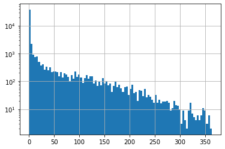

```python
orders['conv_time'].hist(bins=100, log=True)
```

As we can see the time of conversion can during from day to a year.

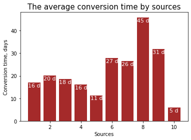

```python
# Study time of conversion by source
users_per_source = visits.groupby('uid')['source_id'].mean().astype('int')
orders = orders.join(users_per_source, on='uid')

time_conv_sources = orders.groupby('source_id')['conv_time'].mean().reset_index()
fig, ax = plt.subplots()
rect=ax.bar(time_conv_sources['source_id'], time_conv_sources['conv_time'], color='brown')
ax.set_ylabel('Conversion time, days')
ax.set_xlabel('Sources')
ax.set_title('The average conversion time by sources', fontdict={'size':15})
for row in time_conv_sources.itertuples():
    ax.text(row.source_id, row.conv_time-2, s=str(int(row.conv_time))+' d',
            fontdict={'horizontalalignment': 'center','size':11, 'color':'white'})
plt.show()
```

How we can see the smallest conversion time has 10th source (5 days) and the largest conversion time belong of the 8th (free) (45 days) and 9th sources (31 days).

```python
# Study how many orders users make during daily, weekly, monthly, totally

# totally orders
orders_per_user = orders.pivot_table(index='uid', values='revenue', aggfunc=['count', 'sum']).reset_index()
orders_per_user.columns=['uid','n_orders', 'revenue']
print('The total number of orders is', len(orders))
print('The total number of unique customers is', orders['uid'].nunique())
print('The total revenue is {:.2f} usd'.format(orders['revenue'].sum()))
print('The total average number of orders per user is {:.2f}. In range from {} to {}'
      .format(orders_per_user['n_orders'].mean(), orders_per_user['n_orders'].min(),
             orders_per_user['n_orders'].max()))
```

```
The total number of orders is 50415
The total number of unique customers is 36523
The total revenue is 252057.20 usd
The total average number of orders per user is 1.38. In range from 1 to 239
```

```python
# monthly orders per user
orders['buy_month'] = orders['buy_date'].dt.strftime('%Y-%m')
orders_per_user_month = orders.pivot_table(index='buy_month', values='revenue',
                                           aggfunc=['count', 'sum'])
orders_per_user_month.columns=['n_orders', 'revenue']
print('The average number of monthly orders is {:.0f}. From {:.0f} to {:.0f}'
      .format(orders_per_user_month['n_orders'].mean(), orders_per_user_month['n_orders'].min(),
             orders_per_user_month['n_orders'].max()))
print('with average amount of revenue {:.2f} usd, from {:.2f} to {:.2f} usd'
      .format(orders_per_user_month['revenue'].mean(), orders_per_user_month['revenue'].min(),
             orders_per_user_month['revenue'].max()))
```

```
The average number of monthly orders is 4201. From 1807 to 6218
with average amount of revenue 21004.77 usd, from 8758.78 to 36388.60 usd
```

```python
# weekly orders

orders['buy_week'] = orders['buy_date'].dt.week
orders_per_user_week = orders.pivot_table(index='buy_week', values='revenue',
                                           aggfunc=['count', 'sum'])
orders_per_user_week.columns=['n_orders', 'revenue']
print('The average number of weekly orders is {:.0f}. In range from {:.0f} to {:.0f}'
      .format(orders_per_user_week['n_orders'].mean(), orders_per_user_week['n_orders'].min(),
             orders_per_user_week['n_orders'].max()))
print('with average amount of revenue {:.2f} usd, from {:.2f} to {:.2f} usd'
      .format(orders_per_user_week['revenue'].mean(), orders_per_user_week['revenue'].min(),
             orders_per_user_week['revenue'].max()))
```

```
The average number of weekly orders is 970. In range from 314 to 1894
with average amount of revenue 4847.25 usd, from 1364.33 to 11470.93 usd
```

```python
# daily orders

orders_per_user_day = orders.pivot_table(index='buy_date', values='revenue',
                                           aggfunc=['count', 'sum'])
orders_per_user_day.columns=['n_orders', 'revenue']
print('The average number of daily orders is {:.0f}. In range from {:.0f} to {:.0f}'
      .format(orders_per_user_day['n_orders'].mean(), orders_per_user_day['n_orders'].min(),
             orders_per_user_day['n_orders'].max()))
print('with average amount of revenue {:.2f} usd, from {:.2f} to {:.2f} usd'
      .format(orders_per_user_day['revenue'].mean(), orders_per_user_day['revenue'].min(),
             orders_per_user_day['revenue'].max()))
```

```
The average number of daily orders is 139. In range from 15 to 814
with average amount of revenue 694.37 usd, from 29.22 to 4661.33 usd
```

```python
# Study orders by sources
orders_sources = orders.groupby('source_id').agg({'uid':['count', 'nunique'], 'revenue':'sum'}).reset_index()
orders_sources.columns=['source_id', 'n_orders', 'n_customers', 'revenue']
orders_sources['orders_per_user'] = (orders_sources['n_orders'] / orders_sources['n_customers']).round(2)
orders_sources['arpu'] = (orders_sources['revenue'] / orders_sources['n_customers']).round(2)
orders_sources['avg_check'] = (orders_sources['revenue'] / orders_sources['n_orders']).round(2)
orders_sources['revenue_share'] = (orders_sources['revenue'] / orders_sources['revenue'].sum()).round(4)
orders_sources
```

|  | source_id | n_orders | n_customers | revenue | orders_per_user | arpu | avg_check | revenue_share |
| --- | --- | --- | --- | --- | --- | --- | --- | --- |
| 0 | 1 | 4520 | 2551 | 36352.44 | 1.77 | 14.25 | 8.04 | 0.1442 |
| 1 | 2 | 10536 | 5628 | 76215.84 | 1.87 | 13.54 | 7.23 | 0.3024 |
| 2 | 3 | 14237 | 10795 | 58209.70 | 1.32 | 5.39 | 4.09 | 0.2309 |
| 3 | 4 | 11353 | 9432 | 45157.22 | 1.20 | 4.79 | 3.98 | 0.1792 |
| 4 | 5 | 6276 | 5337 | 25286.58 | 1.18 | 4.74 | 4.03 | 0.1003 |
| 5 | 6 | 1060 | 765 | 3726.11 | 1.39 | 4.87 | 3.52 | 0.0148 |
| 6 | 7 | 729 | 520 | 2359.41 | 1.40 | 4.54 | 3.24 | 0.0094 |
| 7 | 8 | 116 | 77 | 383.49 | 1.51 | 4.98 | 3.31 | 0.0015 |
| 8 | 9 | 635 | 533 | 1920.19 | 1.19 | 3.60 | 3.02 | 0.0076 |
| 9 | 10 | 953 | 885 | 2446.22 | 1.08 | 2.76 | 2.57 | 0.0097 |

As you can see from the table, the most interesting average revenue per user belongs to sources 1 and 2 (\$14,25 and \\$13,54). They also have a high average check (\$8.04 and \\$7.23).  
Source number 2 also leads to revenue (\$76215.84).  
The 3rd and 4th sources have the largest number of users (10795 and 9432) and the largest number of orders (14237 and 11353).  
Sources 6 through 10 are weak in all parameters.

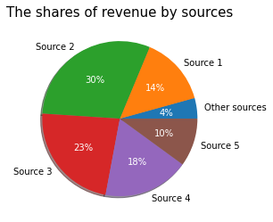

```python
rev_share = orders_sources[['source_id', 'revenue_share']]
rev_share['source_str'] = rev_share.apply(lambda x: 'Source '+str(int(x['source_id']))
                          if x['revenue_share']>=0.1 else 'Other sources', axis=1)
rev_share1 = rev_share.groupby('source_str')['revenue_share'].sum()
p, tx, autotexts = plt.pie(rev_share1, labels=rev_share1.index, autopct='', shadow=True)
for i, a in enumerate(autotexts):
    a.set_text("{:.0%}".format(rev_share1[i]))
    a.set_color(color='white')
plt.title("The shares of revenue by sources", fontsize=15)
plt.show()
```

Source 2 is the largest share of the revenue. Sources 1 through 5 generate more than 95% of revenue.

```python
print('The average size of purshese size is {:.2f} usd'.format(orders_sources['avg_check'].mean()))
```

```
The average size of purshese size is 4.30 usd
```

Judging by the size of the average purchase, the source table 'orders' shows us the service commission as a revenue (usually 10% of the purchase size). Thus, we assume that instead of revenue, we are given a gross profit. And we don't need to use the margin ratio to calculate revenue per user.

```python
# Study how much money users bring?

# Make cohort analysis of orders by months
first_order_months = orders.groupby('uid')['buy_date'].min().dt.strftime('%Y-%m')
first_order_months.name = 'cohort'
orders = orders.join(first_order_months, on='uid')
```